# Differential Equations Introduction

## Goals

1. Solutions: Theoretical computation
2. Visualization
3. Properties of Equations: Stability, time behavior
4. Machine learning: Iuput equations, output numerical scheme

Consider \begin{eqnarray} \frac{d y}{d x} &=& x-y,\ y(x_0)&=&y_0 \end{eqnarray}

Solution is sum of general solution, $y_g$ which satisfies $y_g'+y_g=0$, and special solution, $y_s$ which satisfies $y_s'+y_s=x$ since \begin{eqnarray} y'&=&(y_g+y_s)' \ &= &y_g'+y_s'=-y_g+x-y_s=x-y \end{eqnarray}

## Conclusion

$$ y(x)=e^{x_0} (y_0+1-x_0) e^{-x}+x-1$$

```python
from numpy import *
import numpy as np
import matplotlib.pyplot as plt
%matplotlib inline
```

```python
def f(x,y):                # DE is y'=f(x,y) for
   return x-y              # this function f

def yexact(x,x0,y0):       # exact solution y(x) that satisfies y(x0)=y0
   y=y0*exp(-x + x0) + (x*exp(x) - x0*exp(x0) - exp(x) + exp(x0))*exp(-x)
   return y
```

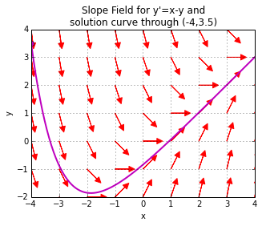

```python
fig=plt.figure(figsize=(5,5))          # fig is figure variable
ax=fig.add_subplot(1,1,1) # in 1x1 array of subplots, ax is subplot 1

#					  I. Slope Field

xmesh=linspace(-4.,4.,9); ymesh=linspace(-4.,4.,9) # x and y mesh values

#                                       plot mini-tangent for
#                                       y'=f(x,y) at each mesh point
for xp in xmesh:
   for yp in ymesh:
      m=f(xp,yp)
      h=0.25/sqrt(1.+m**2)
      #ax.plot([xp-h,xp+h],[yp-m*h,yp+m*h],'b')
      ax.arrow(xp,yp,2*h,2*m*h, head_width=0.2, head_length=0.2, fc='r', ec='r')

#					II. Dot at given (x0,y0) and solution curve through (x0,y0)
x0=-4.; y0=3.5
ax.plot([x0],[y0],'mo') # 'm'agenta d'o't
X=linspace(-4.,4.,101)  # X[0]=-4., .., X[100]=4.
Y=yexact(X,x0,y0)
ax.plot(X,Y,'m',linewidth=2) # lines joining points (X[i],Y[i]), 'm'agenta

ax.set_xlabel('x'); ax.set_ylabel('y')
ax.grid(True)           # add a grid to the plot
ax.set_aspect(1.)       # require that (scaling factor for y)/(scaling factor for x), is 1.
plt.title("Slope Field for y'=x-y and\nsolution curve through ({0:g},{1:g})".format(x0,y0))
#plt.savefig("306ch1_slope_field_soln_1.3.5.png")
#plt.show() # to display immediately
```

## Symbol DE solver

Solve $y'=x-y, y(0)=y_0$

```python
from sympy import Symbol , dsolve , Function , Derivative , Eq, lambdify, symbols,solve
```

```python
x=Symbol('x')
x0,y0=symbols('x0 y0')
y=Function('y')
```

```python
f_=Derivative(y(x),x)-x+y(x)
sol=dsolve(f_,y(x))
```

```python
print sol
```

```
y(x) == (C1 + (x - 1)*exp(x))*exp(-x)
```

```python
yy=sol.rhs
C1=Symbol('C1')
```

```python
z= lambdify(x,sol.rhs-y0)
z(0)
```

```
1.0*C1 - y0 - 1.0
```

```python
c=solve(z(0),C1)
```

```python
ysol=yy.subs({C1:c[0]})
print ysol
```

```
(y0 + (x - 1)*exp(x) + 1.0)*exp(-x)
```

## Steps for Scheme Auto-generated

1. SymPy -> theoretical solution
2. NumPy -> numerical computation
3. Matplotlib -> visualization

```python
def ode1(f,x0,y0):
    sol=dsolve(f,y(x))

    yy=sol.rhs
    C1=Symbol('C1')
    z= lambdify(x,sol.rhs-y0)
    c=solve(z(x0),C1)
    ysol=yy.subs({C1:c[0]})
    return ysol
```

```python
ysol=ode1(f_,0,1)
```

```python
print ysol
```

```
((x - 1)*exp(x) + 2.0)*exp(-x)
```

```python
z=lambdify(x,ysol)
z(1)
```

```
0.7357588823428847
```

```python
t=linspace(-4.,4.,101)
```

```python
def makepic(t,f_,xin,yin):
    yy=np.array([])
    ysol=ode1(f_,xin,yin)
    z=lambdify(x,ysol)
    for t1 in t:
        yy=append(yy,z(t1))
    plt.plot(t,yy,'r--')

def yexact(t,f_,xmesh,ymesh):
    plt.figure(figsize=(5,5))
    plt.xlim(-4,4)
    plt.ylim(-4,4)
    for xp in xmesh:
        for yp in ymesh:
            makepic(t,f_,xp,yp)
    yy=np.array([])
    ysol=ode1(f_,0,1)
    z=lambdify(x,ysol)
    for t1 in t:
        yy=append(yy,z(t1))
    plt.plot(t,yy,'b')
```

```python
xmesh=linspace(-4.,4.,9);
ymesh=linspace(-4.,4.,9);
```

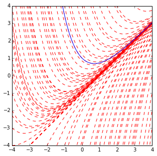

```python
yy=yexact(t,f_,xmesh,ymesh)
```

## Notes

1. If $x-y=0$, $y'=0$ implies $ (x_0,y_0)=(x_0,x_0) $ being equilibrium.
2. If $ x_0 >y_0$, $y'(x_0^+)>0 \to y$ increaseing and $y\sim x (\to \infty)$ as $x\to \infty$
3. If $ x_0 <y_0$, $y'(x_0^+)<0 \to y$ decreasing and then increasing ( since $C_1\exp(-x)<x$ eventually and referece above graph) and $y\to \infty$ as $x\to -\infty$

Question:

Explain the results in above note from the theoretical solution of $y(x)$.